# R4DS_2E_factors

Martin

2026-01-19

## Factors - General Social Survey

1. Explore the distribution of rincome (reported income). What makes the default bar chart hard to understand? How could you improve the plot?

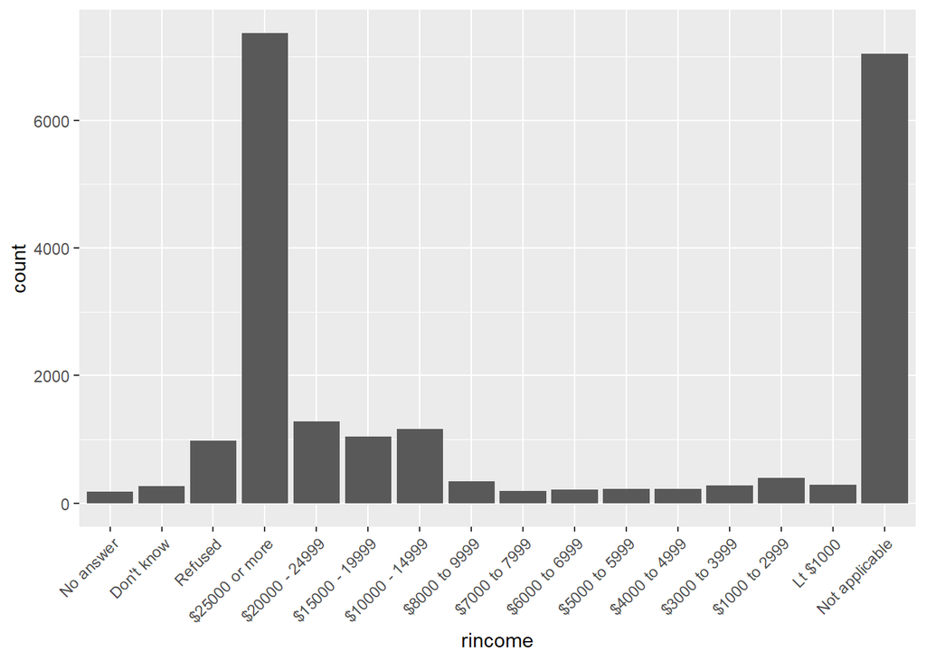

```r
gss_cat |>
  ggplot(aes(rincome)) +
  geom_bar()  +
  theme(axis.text.x = element_text(angle = 45, hjust = 1))
```

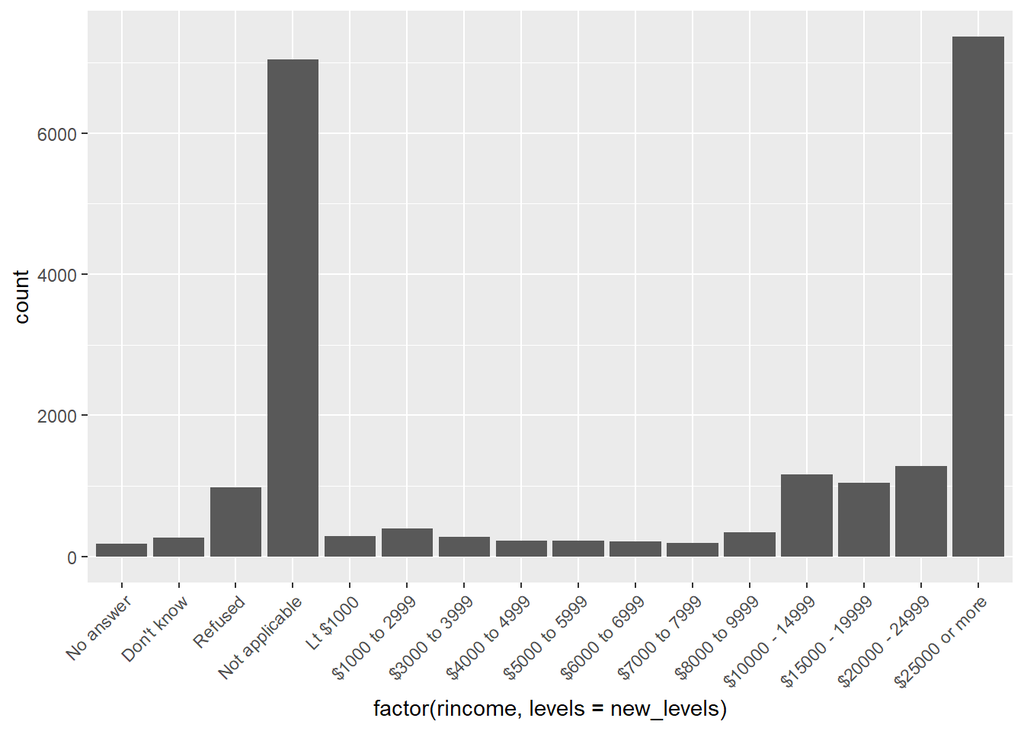

```r
# There appears to be some order with the ranges of income generally going down, with Not applicable seeming to indicate someone with no source of reported income. Generally income should go up from left to right so I would probably change that. The answers that are effectively non-answers such as "No answer", "Don't know" and "Refused" are all grouped together which makes sense.

rev_levels <- rev(levels(gss_cat$rincome))[1:13]
new_levels <- c("No answer", "Don't know", "Refused", rev_levels)

gss_cat |>
  ggplot(aes(factor(rincome, levels = new_levels))) +
  geom_bar()  +
  theme(axis.text.x = element_text(angle = 45, hjust = 1))
```

```r
# Could also improve the plot by making better groupings of the ranges, changing axis titles etc.
```

2. What is the most common relig in this survey? What’s the most common partyid?

```r
gss_cat |>
  count(relig, sort = TRUE)
```

```
## # A tibble: 15 × 2
##    relig                       n
##    <fct>                   <int>
##  1 Protestant              10846
##  2 Catholic                 5124
##  3 None                     3523
##  4 Christian                 689
##  5 Jewish                    388
##  6 Other                     224
##  7 Buddhism                  147
##  8 Inter-nondenominational   109
##  9 Moslem/islam              104
## 10 Orthodox-christian         95
## 11 No answer                  93
## 12 Hinduism                   71
## 13 Other eastern              32
## 14 Native american            23
## 15 Don't know                 15
```

```r
# Protestantism if the most popular

gss_cat |>
  count(partyid, sort = TRUE)
```

```
## # A tibble: 10 × 2
##    partyid                n
##    <fct>              <int>
##  1 Independent         4119
##  2 Not str democrat    3690
##  3 Strong democrat     3490
##  4 Not str republican  3032
##  5 Ind,near dem        2499
##  6 Strong republican   2314
##  7 Ind,near rep        1791
##  8 Other party          393
##  9 No answer            154
## 10 Don't know             1
```

```r
# Independents are the most popular
```

3. Which relig does denom (denomination) apply to? How can you find out with a table? How can you find out with a visualization?

```r
gss_cat |>
  group_by(relig, denom) |>
  summarize(n = n())
```

```
## # A tibble: 47 × 3
## # Groups:   relig [15]
##    relig                   denom               n
##    <fct>                   <fct>           <int>
##  1 No answer               No answer          93
##  2 Don't know              Not applicable     15
##  3 Inter-nondenominational Not applicable    109
##  4 Native american         Not applicable     23
##  5 Christian               No answer           2
##  6 Christian               Don't know         11
##  7 Christian               No denomination   452
##  8 Christian               Not applicable    224
##  9 Orthodox-christian      Not applicable     95
## 10 Moslem/islam            Not applicable    104
## # ℹ 37 more rows
```

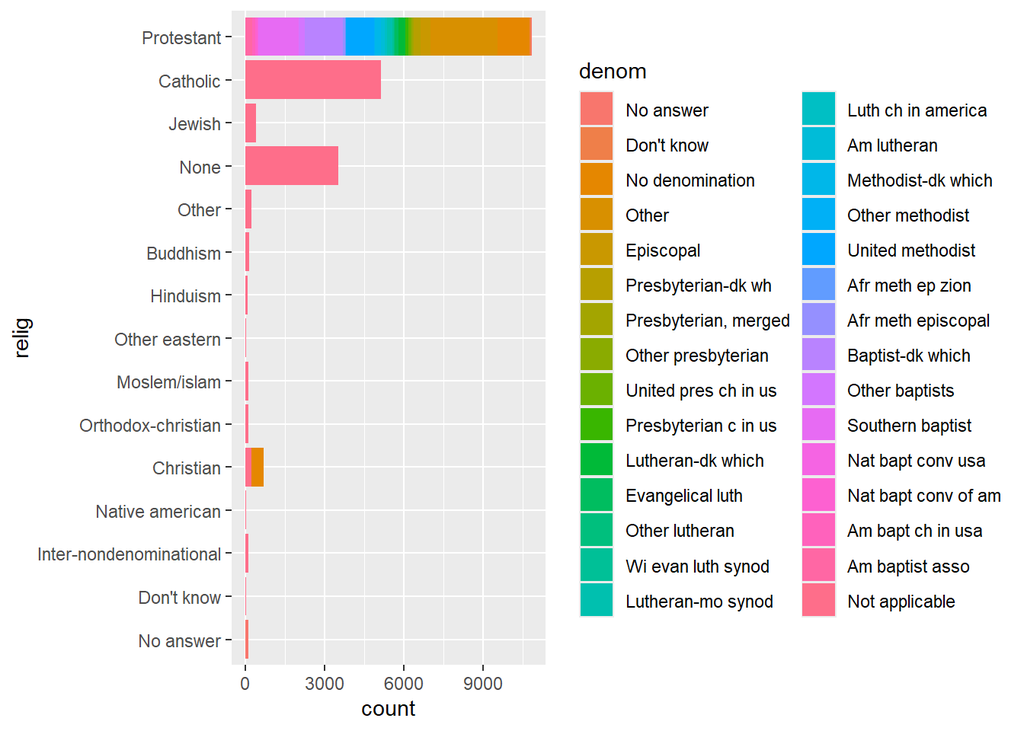

```r
# Looking at this table we see that Native Americans, Christians etc. answered either, No answer, Don't Know, No denomination, Not applicable etc. which suggests that denom doesn't apply to these religions. The only religious group that has answers other than the ones listed above is Protestants, with many denominations such as Episcopal,    Presbyterian and Lutheran just to name a few.

gss_cat |>
  group_by(relig, denom) |>
  ggplot(aes(y = relig, fill = denom)) +
  geom_bar()
```

```r
# We can see that Protestant is the entire reason as to why the legend is so large
```

## Factors - Modifying factor order

1.There are some suspiciously high numbers in tvhours. Is the mean a good summary?

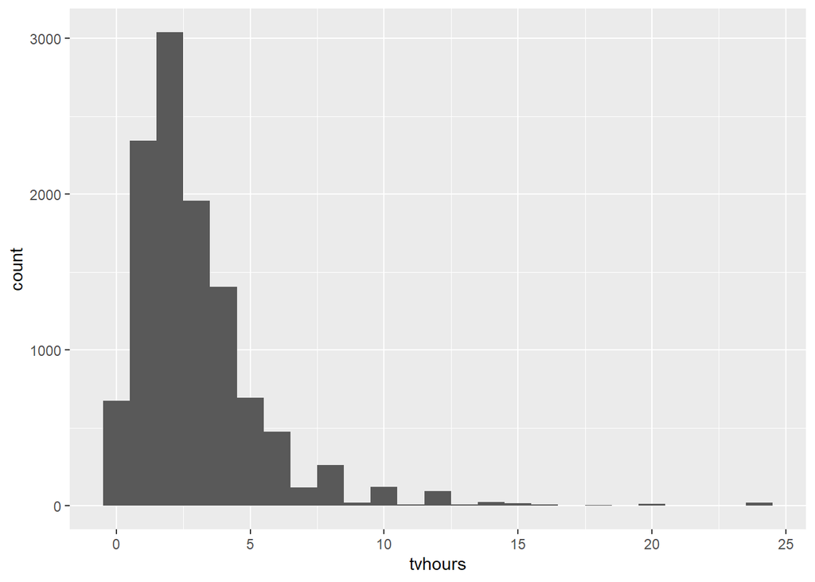

```r
gss_cat |>
  ggplot(aes(x = tvhours)) +
  geom_histogram(binwidth = 1)
```

```r
# There are definitely some erroneous entries. Anything above 16 hours I would wager are erroneous and still I would question why some people would respond that they watch TV on average for 10-16 hours a day however it seems plausible so we can keep them. Given these outlier values the mean probably isn't as good a summary. We should use the median instead

median(gss_cat$tvhours, na.rm = TRUE)
```

```
## [1] 2
```

2. For each factor in gss_cat identify whether the order of the levels is arbitrary or principled.

```r
# Apply is.factor check to every column in gss_cat
gss_cat_factors <- gss_cat[, sapply(gss_cat, is.factor)]
gss_cat_vars <- colnames(gss_cat_factors)

# Loop through the levels of each variable
for (var in gss_cat_vars) {
  cat("Variable:", var, "\n")
  cat("Levels:", levels(gss_cat[[var]]), "\n\n")
}
```

[output not shown]

```r
# While we can get a lot of information just by looking at the order of the levels as to whether it is an arbitrary ordering or not, we should still plot the counts of each of these as they may be ordered by count. Using the levels overview, I think marital, race, and relig are probably arbitary. rincome isn't as there is a clear ordering for the different income buckets. partyid ranges from strong republican, to independents to strong democrat in an orderly fashion. Given the question we looked at in chunk 4, I imagine denom has been ordered by count.
```

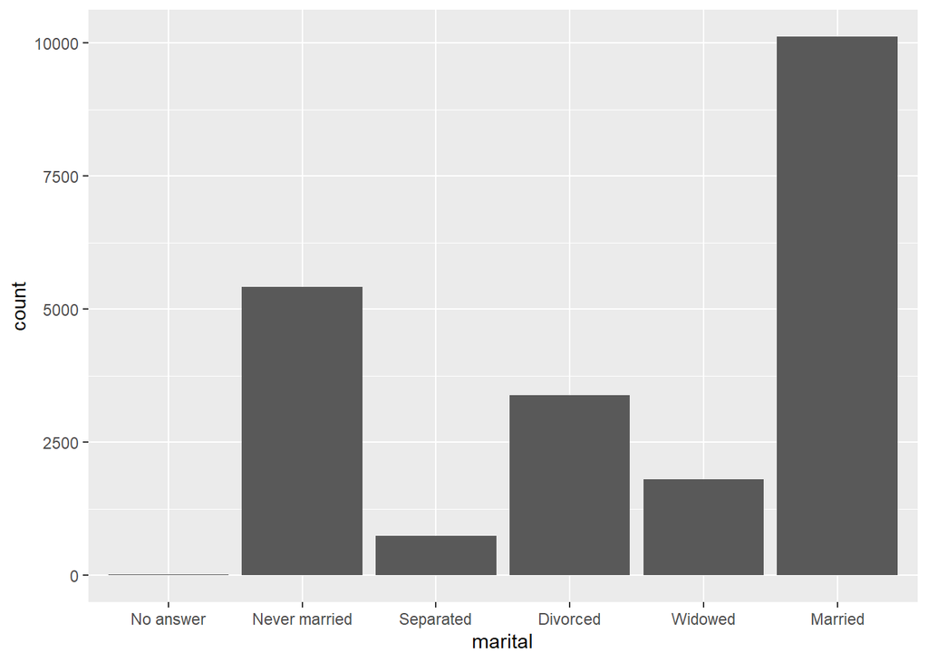

```r
gss_cat |>
  ggplot(aes(x = marital)) +
  geom_bar()
```

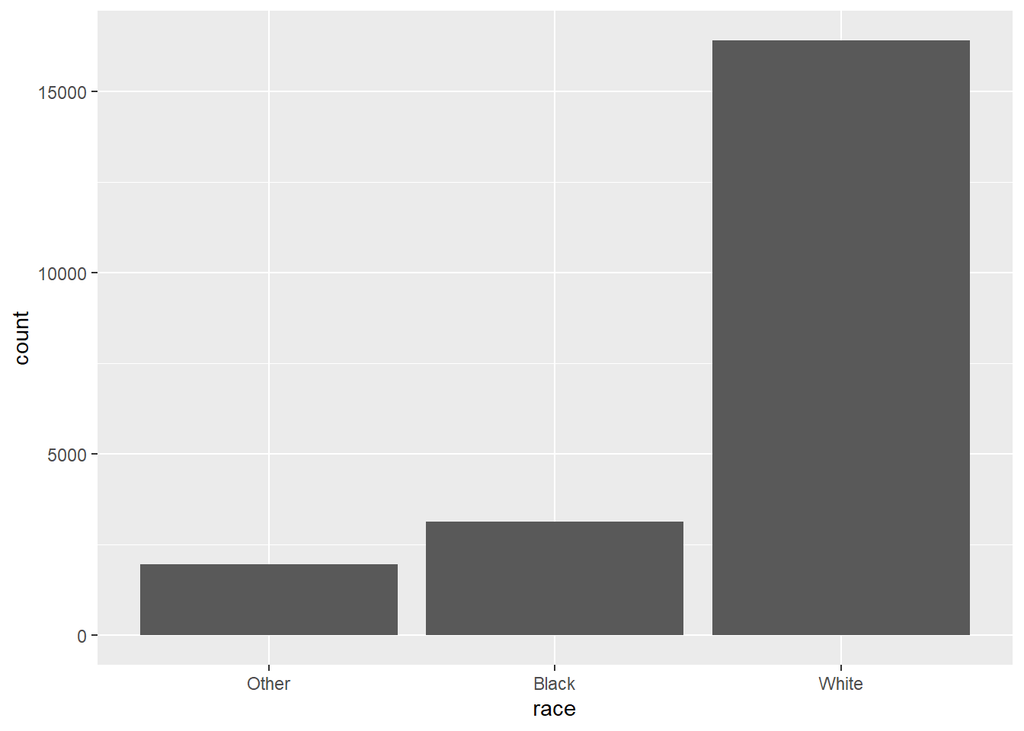

```r
# Doesn't seem to be count based, or based on the actual possible answers, as I would think Never married and Married would be next to each other.

gss_cat |>
  ggplot(aes(x = race)) +
  geom_bar()
```

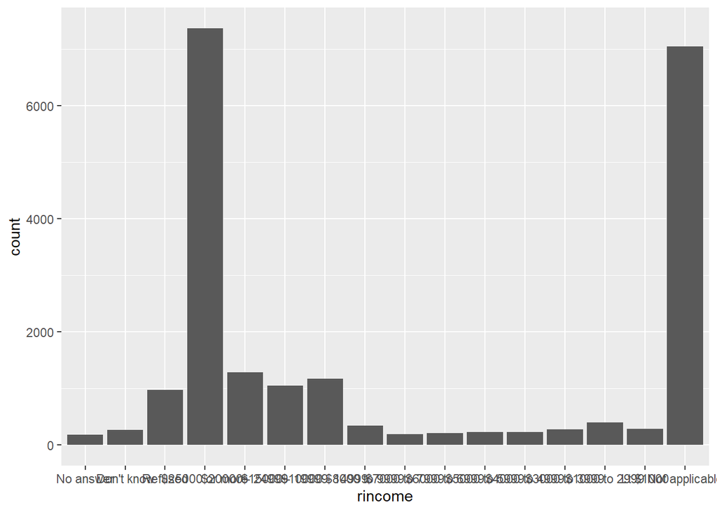

```r
# I think maybe race isn't abitrary and is based on ascending count order

gss_cat |>
  ggplot(aes(x = rincome)) +
  geom_bar()
```

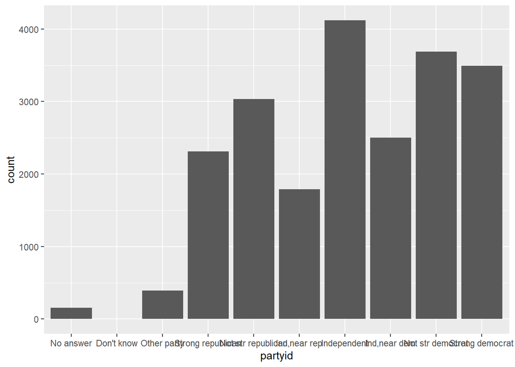

```r
# We saw this one in Chunk 4. There is some principled order to it

gss_cat |>
  ggplot(aes(x = partyid)) +
  geom_bar()
```

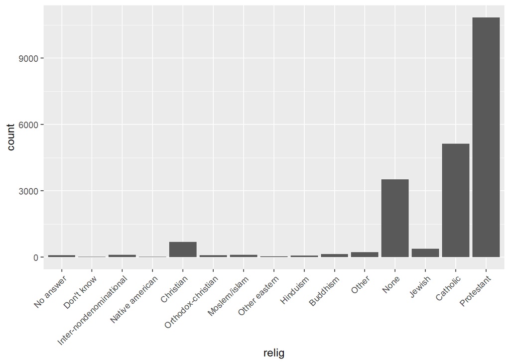

```r
# See above chunks arguments. This is principled

gss_cat |>
  ggplot(aes(x = relig)) +
  geom_bar() +
  theme(axis.text.x = element_text(angle = 45, hjust = 1))
```

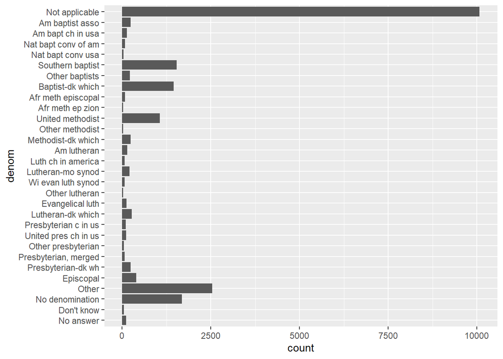

```r
# It appears maybe similar region religions are grouped together? However the answers "Other" and "None" are just randomly slapped near the middle right of the plot, so my guess is this is arbitrary

gss_cat |>
  ggplot(aes(y = denom)) +
  geom_bar()
```

```r
# Despite what the plot might tell you, its likely principled. We saw that denominations only really correspond to if you're a Protestant or not. All the Protestant denominations are grouped together.
```

3. Why did moving “Not applicable” to the front of the levels move it to the bottom of the plot?

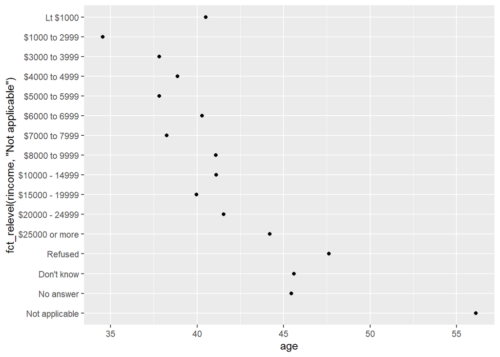

```r
# They are refering to the following plot in the book:
rincome_summary <- gss_cat |>
  group_by(rincome) |>
  summarize(
    age = mean(age, na.rm = TRUE),
    n = n()
  )

ggplot(rincome_summary, aes(x = age, y = fct_relevel(rincome, "Not applicable"))) +
  geom_point()
```

```r
# Because we used `fct_relevel` which takes a factor, f (in this case rincome), and then any number of levels that you want to move to the front of the line (in this case "Not applicable"). The front most entries will appear at the bottom.
```

## Factors - Modifying factor levels

1. How have the proportions of people identifying as Democrat, Republican, and Independent changed over time?

```r
gss_cat_prtyid <- gss_cat |>
  mutate(
    partyid = fct_collapse(partyid,
      "other" = c("No answer", "Don't know", "Other party"),
      "rep" = c("Strong republican", "Not str republican"),
      "ind" = c("Ind,near rep", "Independent", "Ind,near dem"),
      "dem" = c("Not str democrat", "Strong democrat")
    )
  ) |>
  group_by(year, partyid) |>
  summarise(n = n()) |>
  group_by(year) |>
  mutate(n_year = sum(n),
         prop_partyid = n / n_year) |>
  ungroup()
```

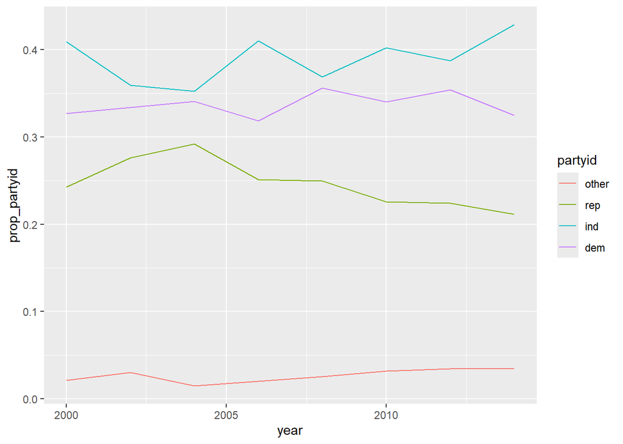

```r
gss_cat_prtyid |>
  ggplot(aes(x = year, y = prop_partyid, colour = partyid)) +
  geom_line()
```

```r
# Other has remained relatively the same, republican has continued to drop since about 2004 when it was at its peak. Independent has gone up and down but is trending upwards more recently. Democrat support appears to remain the same with it being slightly higher in more recent years.
```

2. How could you collapse rincome into a small set of categories?

```r
levels(gss_cat$rincome)
```

```
##  [1] "No answer"      "Don't know"     "Refused"        "$25000 or more"
##  [5] "$20000 - 24999" "$15000 - 19999" "$10000 - 14999" "$8000 to 9999"
##  [9] "$7000 to 7999"  "$6000 to 6999"  "$5000 to 5999"  "$4000 to 4999"
## [13] "$3000 to 3999"  "$1000 to 2999"  "Lt $1000"       "Not applicable"
```

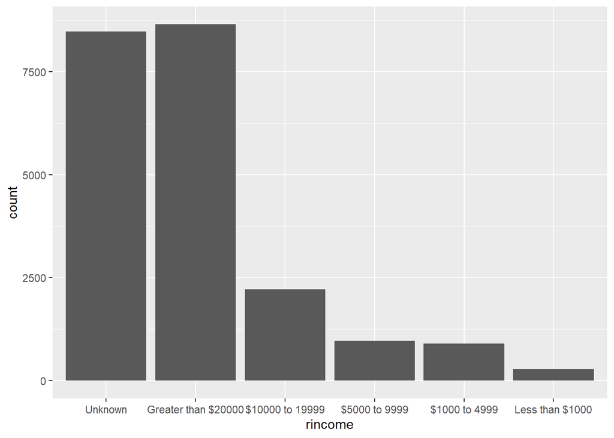

```r
gss_cat_rincome <- gss_cat |>
  mutate(
    rincome = fct_collapse(rincome,
      "Unknown" = c("No answer", "Don't know", "Refused", "Not applicable"),
      "Less than $1000" = c("Lt $1000"),
      "$1000 to 4999" = c("$1000 to 2999", "$3000 to 3999", "$4000 to 4999"),
      "$5000 to 9999" = c("$5000 to 5999", "$6000 to 6999", "$7000 to 7999", "$8000 to 9999"),
      "$10000 to 19999" = c("$10000 - 14999", "$15000 - 19999"),
      "Greater than $20000" = c("$20000 - 24999", "$25000 or more")
    )
  )

gss_cat_rincome |>
  ggplot(aes(rincome)) +
  geom_bar()
```

3. Notice there are 9 groups (excluding other) in the fct_lump example above. Why not 10? (Hint: type ?fct_lump, and find the default for the argument other_level is “Other”.)

```r
# Referring to the following code:
gss_cat |>
  mutate(relig = fct_lump_n(relig, n = 10)) |>
  count(relig, sort = TRUE)
```

```
## # A tibble: 10 × 2
##    relig                       n
##    <fct>                   <int>
##  1 Protestant              10846
##  2 Catholic                 5124
##  3 None                     3523
##  4 Christian                 689
##  5 Other                     458
##  6 Jewish                    388
##  7 Buddhism                  147
##  8 Inter-nondenominational   109
##  9 Moslem/islam              104
## 10 Orthodox-christian         95
```

```r
# To be more clear, the question is asking us why aren't there ten groups and another group "Other" which buckets the rest of the religions if they don't "fit". Currently there is only 9.

?fct_lump
```

```
## starting httpd help server ... done
```

```
#> other_level  Value of level used for "other" values. Always placed at end of levels.
```

```r
# The default is "Other". Lets change this parameter to a different argument and see what happens
gss_cat |>
  mutate(relig = fct_lump_n(relig, n = 10, other_level = "Else")) |>
  count(relig, sort = TRUE)
```

```
## # A tibble: 11 × 2
##    relig                       n
##    <fct>                   <int>
##  1 Protestant              10846
##  2 Catholic                 5124
##  3 None                     3523
##  4 Christian                 689
##  5 Jewish                    388
##  6 Else                      234
##  7 Other                     224
##  8 Buddhism                  147
##  9 Inter-nondenominational   109
## 10 Moslem/islam              104
## 11 Orthodox-christian         95
```

```r
# Now we have 10 groups excluding our other_level, "Else". If we look at the levels of relig in gss_cat we can get a better understanding of whats happening and why.

levels(gss_cat$relig)
```

```
##  [1] "No answer"               "Don't know"
##  [3] "Inter-nondenominational" "Native american"
##  [5] "Christian"               "Orthodox-christian"
##  [7] "Moslem/islam"            "Other eastern"
##  [9] "Hinduism"                "Buddhism"
## [11] "Other"                   "None"
## [13] "Jewish"                  "Catholic"
## [15] "Protestant"              "Not applicable"
```

```r
# The original dataset already has a group in relig called "Other", so what happened is it combined the total count from all the religious groups that didn't make it into the top 10 (n = 234) with the group "Other" which was already an option (n = 224). Notice how the code in the book makes sense of this as "Other" has an n value of 458 (which is 234 + 224)
```